# The Dilemma of Holding on for One more Day: Oviductal egg retention as an energetically inexpensive mechanism to facilitate flexibility in reproductive phenology in gravid female Eastern Musk Turtles 

```r
modlm<- lm(Gravid_J~  Clutch_Size, data=egg_J)
summary(modlm)
```

```
Call:
lm(formula = Gravid_J ~ Clutch_Size, data = egg_J)

Residuals:
   Min     1Q Median     3Q    Max
-33.30  -4.20   0.00   6.94  19.42

Coefficients:
                 Estimate Std. Error t value Pr(>|t|)
(Intercept)        107.96      16.19    6.67  5.6e-05 ***
Clutch_SizeFour      4.28      17.17    0.25     0.81
Clutch_SizeSix     -13.44      22.90   -0.59     0.57
Clutch_SizeThree    -3.26      18.10   -0.18     0.86
Clutch_SizeTwo     -29.71      22.90   -1.30     0.22
---
Signif. codes:  0 ‘***’ 0.001 ‘**’ 0.01 ‘*’ 0.05 ‘.’ 0.1 ‘ ’ 1

Residual standard error: 16.2 on 10 degrees of freedom
Multiple R-squared:  0.318, Adjusted R-squared:  0.0447
F-statistic: 1.16 on 4 and 10 DF,  p-value: 0.383
```

```r
modlm<- lm(Gravid_J~  Egg_Mass_g, data=egg_J)
summary(modlm)
```

```
Call:
lm(formula = Gravid_J ~ Egg_Mass_g, data = egg_J)

Residuals:
   Min     1Q Median     3Q    Max
-26.81  -6.80   2.46   8.57  22.20

Coefficients:
            Estimate Std. Error t value Pr(>|t|)
(Intercept)    66.57      17.46    3.81   0.0022 **
Egg_Mass_g      2.85       1.22    2.34   0.0358 *
---
Signif. codes:  0 ‘***’ 0.001 ‘**’ 0.01 ‘*’ 0.05 ‘.’ 0.1 ‘ ’ 1

Residual standard error: 14.4 on 13 degrees of freedom
Multiple R-squared:  0.297, Adjusted R-squared:  0.242
F-statistic: 5.48 on 1 and 13 DF,  p-value: 0.0358
```

```r
modlm<- lm(Gravid_J~  Female_Mass_g, data=egg_J)
summary(modlm)
```

```
Call:
lm(formula = Gravid_J ~ Female_Mass_g, data = egg_J)

Residuals:
   Min     1Q Median     3Q    Max
-29.80  -8.01   2.04  12.45  16.26

Coefficients:
              Estimate Std. Error t value Pr(>|t|)
(Intercept)     55.677     21.781    2.56    0.024 *
Female_Mass_g    0.369      0.156    2.37    0.034 *
---
Signif. codes:  0 ‘***’ 0.001 ‘**’ 0.01 ‘*’ 0.05 ‘.’ 0.1 ‘ ’ 1

Residual standard error: 14.4 on 13 degrees of freedom
Multiple R-squared:  0.301, Adjusted R-squared:  0.248
F-statistic: 5.61 on 1 and 13 DF,  p-value: 0.0341
```

```r
egg_J$Clutch_Size<- factor(egg_J$Clutch_Size, levels = c("Two", "Three", "Four", "Five","Six"))
```

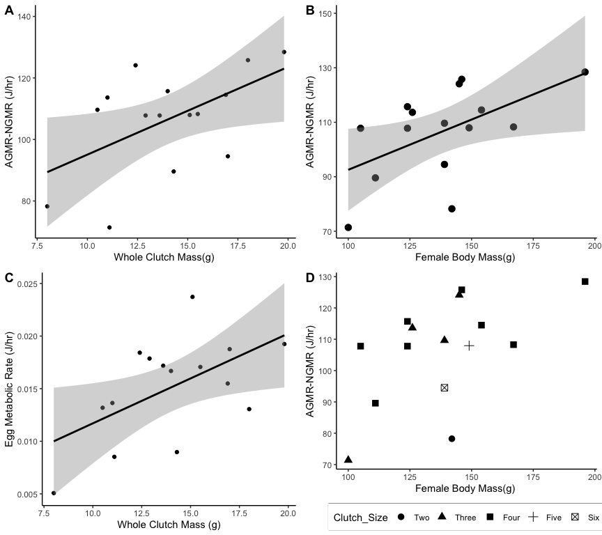

```r
plot_grid(plot2,plot4,plot1, plot3, labels=c('A','B','C', 'D'))
```

### Discusssion

- Gravid females had a ~40% increase in metabolism while gravid, an increased energetic cost of reproduction associated with oviductal egg retention.
- Metabolic costs associated with egg retention were relatively constant across days leading up to oviposition, potentially due to the state of developmental arrest of the embryos.
- The energetic costs of oviductal egg retention were affected by the total clutch metabolism and whole clutch mass.
- Further, metabolic rates of gravid females were significantly elevated from males and non-gravid females indicating a substantial metabolic cost of reproduction for gravid females.
- Eastern Musk Turtles (Sternotherus odoratus) energetic costs towards retaining eggs during oviductal egg production was more than double that of what was observed for Eastern Box Turtles (Terrapene carolina); 16% increase in energy compared to non-gravid energy investments (Clinger 2016).

## Conclusion

Our study suggests that allocating reproductive resources towards extended oviductal egg retention is energetically expensive for S. odoratus. Though a costly strategy for gravid musk turtles, oviductal egg retention may offer advantageous characteristics for the clutch offered up by the microclimates in which they are laid. The difference we saw between S. odoratus and T. carolina in metabolic costs (~40% and 16.7% respectively) could be a result of differing life histories, although without additional references it is unclear how costs would change within and among conspecifics. Taxa that have similar life history patterns should have similar energetic costs associated with oviductal egg retention. Furthermore, comparative studies of related taxa that vary in timing of oviductal egg retention will help to determine the consequences and benefits of extended egg retention.